# Презентация по индивидуальному проекту № 2

Основы информационной безопасности

Луангсуваннавонг Сайпхачан

# Информация

## Докладчик

- Луангсуваннавонг Сайпхачан
- студент группы НКАбд-01-24
- Российский университет дружбы народов им. П. Лумумбы
- https://github.com/sayprachanh-lsvnv

## Цель работы

Приобретение практических навыков по установке DVWA.

## Задание

Установка DVWA в Kali Linux

# Выполнение работы

## Выполнение работы

Сначала я перехожу в папку веб-сервера в корневом каталоге и загружаю DVWA через Github.

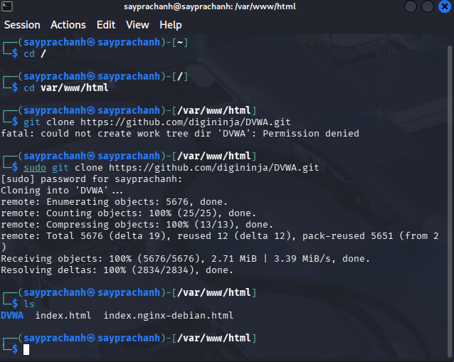

Загрузка DVWA

## Выполнение работы

Я изменяю права доступа к папке на 777.

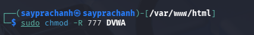

Изменение разрешения доступа к файлу

## Выполнение работы

Затем я перехожу в папку DVWA, проверяю содержимое папки, нахожу и проверяю папку ‘config’.

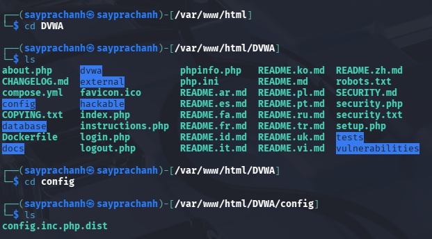

Проверка содержимого папки

## Выполнение работы

Я переименовываю файл config.inc.php.dist в config.inc.php, затем открываю файл для редактирования с помощью текстового редактора. В файле config.inc.php я изменяю информацию о базе данных, меняю пароль на ‘password’ и пользователя на ‘admin’, затем сохраняю и выхожу из файла.

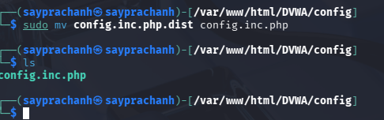

Изменение имени файла

## Выполнение работы

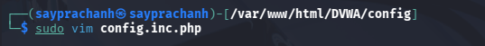

Редактирование файла

## Выполнение работы

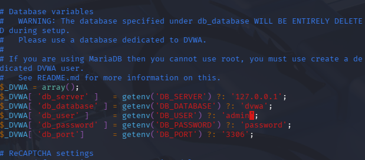

Редактирование файла

## Выполнение работы

Затем с помощью команды systemctl я запускаю службу MySQL, чтобы создать новую базу данных. Поскольку MySQL уже установлен по умолчанию, я могу запустить его сразу, затем проверяю статус процесса.

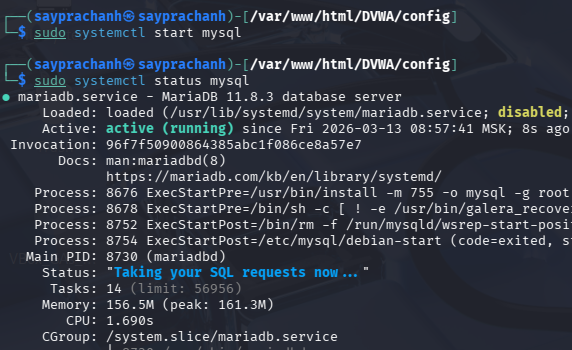

Запуск MySQL

## Выполнение работы

Я вхожу в MySQL как root, сервис использует приглашение ‘MariaDB’, затем начинаю создавать базу данных для нового пользователя в нем.

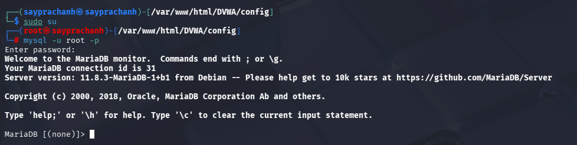

вход в MySQL

## Выполнение работы

Я начинаю с создания новой базы данных ‘dvwa’, с именем и паролем в соответствии с файлом config.inc.php, а также предоставляю пользователю привилегии для работы с этой базой данных.

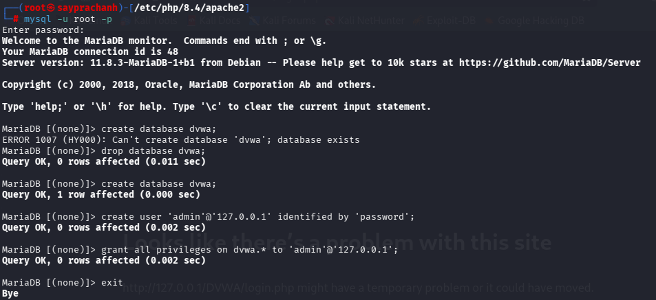

Создание базы данных

## Выполнение работы

После этого я выхожу из службы MySQL и запускаю веб-сервер Apache, а затем проверяю статус веб-сервера.

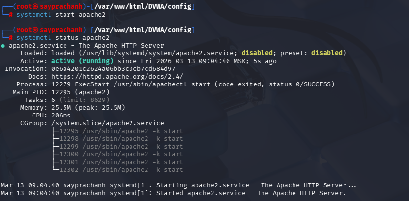

Запуск веб-сервера

## Выполнение работы

Далее необходимо выполнить некоторые настройки файла php.ini в папке Apache2, поэтому я перехожу в эту папку и открываю его в текстовом редакторе.

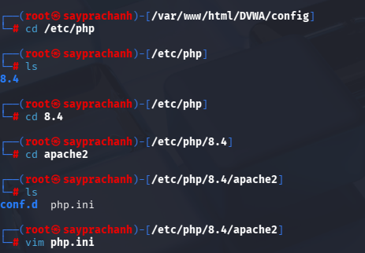

Переход к настройке веб-сервера

## Выполнение работы

В файле я ищу конкретное ключевое слово ‘fopen’, затем изменяю настройку allow_url_include с ‘Off’ на ‘On’, так как оба параметра файла allow_url_fopen и allow_url_include должны быть изменены на ‘On’. После этого я сохраняю и выхожу из файла, и снова перезапускаю веб-сервер.

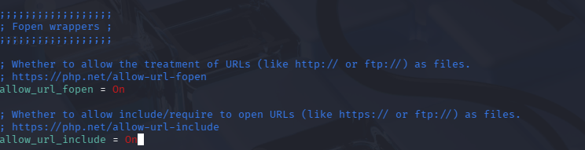

Редактирование файла

## Выполнение работы

Я открываю браузер и ввожу 127.0.0.1/DVWA. Так как у нас уже есть база данных, а также настроен веб-сервер, мы можем войти в веб-приложение через этот URL.

Затем я просто ввожу имя и пароль, которые установил ранее, и попадаю на страницу настройки.

[figure not shown]

Вход на веб-сервер

## Выполнение работы

[figure not shown]

Страница входа

## Выполнение работы

[figure not shown]

Страница настройки

## Выполнение работы

Я прокручиваю страницу вниз и нажимаю кнопку ‘Create / Reset Database’, которая снова запросит имя и пароль.

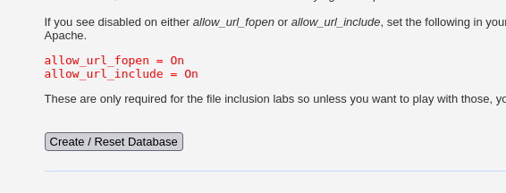

Создание/ сброс базы данных

## Выполнение работы

[figure not shown]

Страница входа

## Выполнение работы

Затем я попадаю на домашнюю страницу веб-приложения и завершаю установку.

[figure not shown]

Домашняя страница

## Выводы

Я приобрел практические навыки по установке DVWA